# Getting started with the SPLITT library

Venelin Mitov

# Before you start

Before you consider using the **SPLITT** C++ library, try to answer the following questions for yourself.

## Do you use pre-order or post-order traversal of a tree-like data-structure?

If you don’t understand what I mean, chances are high that you simply do not need to deal with **SPLITT** at that point. The reason is that I wrote **SPLITT** to solve a very specific problem, which I’ve encountered many times during my doctoral studies: perform the same type of calculation for all nodes in a *large tree*, where each node is related to some specific data and the calculation for one node uses as input the result from the calculation performed on its *daughter nodes*. This is what I mean by *post-order traversal*. A *pre-order traversal* is the same with only one difference – replace the term *daughter nodes* with the term *parent node* in the sentence above.

## How big are your trees and how complex is your node traversal operation?

When I said *large tree* I meant a tree of more than 100 tips, sometimes, more than 10000 tips. This is not a hard rule of thumb, but typically parallel traversal has a performance benefit only on big trees. This depends on other factors as well, such as the computational and memory complexity of the node traversal operation. If the tree is relatively small and the operation is very simple (e.g. the addition or multiplication of a few double-precision numbers), then it is very likely that using **SPLITT** in parallel mode would not be faster than using it in serial mode. Yet, using **SPLITT** might still be a good idea if you currently have an implementation in R and wish to have a faster C++ version - in this case a serial **SPLITT**-based implementation is probably going to between 10 and 100 times faster than the R-implementation.

## Do you need the tree-traversal to be fast?

This very much depends on how frequently do you need to perform the tree-traversal. If you only need to do it once or a couple of times with a given dataset, then I don’t see much need of speeding this up. In my specific use-case, I needed to run a tree traversal millions of times and this was by far the heaviest computational operationduring the analysis of my biological data. It  
would not be an exaggeration, if I say that,without **SPLITT**, my PhD would have needed several more decades of computation time on a modern high performance computing cluster. Thanks to the fast C++ implementation of my models, based on **SPLITT**, I was able to tune my models by running many more analyses with different parameter settings, such as prior distributions for a Bayesian model inference.

## Do you have a program solving your computational problem in a higher level language, e.g. R?

If you don’t, I recommend not trying **SPLITT**, before you have written that program. One reason for that is that, as every C++ code, **SPLITT** needs to be compiled before it can be run. Because you will be including the file “SPLITT.h” in your program, it will be re-compiled every time you make a change in your program and wish to test it. Typically, this would needs about two minutes. Hence, you risk to spend hours or days if you are heavily debugging your C++ code. Of course, if you only know how to program in C++, then no need to learn R now - stick to C++ but be prepared with some snacks and coffee.

# The easiest way to start using **SPLITT**

Being a software library **SPLITT** does not provide a high-level end-user interface. Rather, **SPLITT** is used via its application programming interface (API). In other words, you use the library by putting your application specific code in several C++ classes. The easiest way to do this is to start from an example of such classes and use this example as a skeleton for your own code, i.e. replace the code in the example with your application specific data-types, and traversal operations. Because I was using **SPLITT** mostly from an R-package, at present, there is only an R-package example. Even if you are not familiar with R, this guide should still help you understand how to use **SPLITT** from within your C++ program.

## Installing the **SPLITT** R-package

I recommend installing the latest package version from github. From the R-prompt, type the following command:

```r
devtools::install_github("venelin/SPLITT")
```

## See if it works on your computer

```r
library(SPLITT)
MiniBenchmark(N=10, Ntests = 1000)
```

```
## Performing a mini-benchmark of the POUMM log-likelihood calculation with
##       a tree of size N= 10 ;
## Calling each likelihood calculation Ntests= 1000  times ...
## CPU:  Intel(R) Core(TM) i7-4850HQ CPU @ 2.30GHz
## OpenMP version:  201107
## Number of threads: 8
## Measuring likelihood calculation times...
##     model                                            mode time (ms) speedupX
##  1:   PMM                                      R (serial)     0.230   1.0000
##  2:   PMM                                      C++ (AUTO)     0.015  15.3333
##  3:   PMM              C++ (SINGLE_THREAD_LOOP_POSTORDER)     0.012  19.1667
##  4:   PMM                 C++ (SINGLE_THREAD_LOOP_PRUNES)     0.015  15.3333
##  5:   PMM                 C++ (SINGLE_THREAD_LOOP_VISITS)     0.012  19.1667
##  6:   PMM                  C++ (MULTI_THREAD_LOOP_PRUNES)     0.060   3.8333
##  7:   PMM                  C++ (MULTI_THREAD_LOOP_VISITS)     0.135   1.7037
##  8:   PMM C++ (MULTI_THREAD_LOOP_VISITS_THEN_LOOP_PRUNES)     0.065   3.5385
##  9:   PMM                  C++ (MULTI_THREAD_VISIT_QUEUE)     0.253   0.9091
## 10:   PMM     C++ (MULTI_THREAD_LOOP_PRUNES_NO_EXCEPTION)     0.046   5.0000
## 11:   PMM                        C++ (HYBRID_LOOP_PRUNES)     0.046   5.0000
## 12:   PMM                        C++ (HYBRID_LOOP_VISITS)     0.050   4.6000
## 13:   PMM       C++ (HYBRID_LOOP_VISITS_THEN_LOOP_PRUNES)     0.036   6.3889
```

```r
library(ape)
newick <- '(((1:3,2:2.8)6:4.2,3:4.1)7:4.5,(4:4,5:5)8:6)0;'
tree <- read.tree(text=newick)

x0 <- 0.1
sigma2 <- 0.25
sigmae2 <- 1

set.seed(1)
g <- rTraitCont(tree, model = "BM", root.value = x0,
                sigma = sqrt(sigma2),
                ancestor = FALSE)

x <- g + rnorm(n = length(tree$tip.label), mean = 0, sd = sqrt(sigmae2))

PMMLogLikCpp(x, tree, x0, sigma2, sigmae2, mode = 1)
```

```
## [1] -8.157
```

```cpp
#ifndef AbcPMM_H_
#define AbcPMM_H_

#include "./SPLITT.h"
#include "./NumericTraitData.h"
#include <iostream>
#include <cmath>

namespace SPLITT {

template<class Tree>
class AbcPMM: public TraversalSpecification<Tree> {

public:
  typedef AbcPMM<Tree> MyType;
  typedef TraversalSpecification<Tree> BaseType;
  typedef Tree TreeType;
  typedef PostOrderTraversal<MyType> AlgorithmType;
  typedef vec ParameterType;
  typedef NumericTraitData<typename TreeType::NodeType> DataType;
  typedef vec StateType;

  double sigmae2, sigma2;
  vec x;
  vec a, b, c;

  AbcPMM(TreeType const& tree, DataType const& input_data):
    BaseType(tree) {

    if(input_data.x_.size() != this->ref_tree_.num_tips()) {
      std::ostringstream oss;
      oss<<"The vector x must be the same length as the number of tips ("<<
        this->ref_tree_.num_tips()<<"), but were"<<input_data.x_.size()<<".";
      throw std::invalid_argument(oss.str());
    } else {

      uvec ordNodes = this->ref_tree_.OrderNodes(input_data.names_);
      this->x = At(input_data.x_, ordNodes);
      this->a = vec(this->ref_tree_.num_nodes());
      this->b = vec(this->ref_tree_.num_nodes());
      this->c = vec(this->ref_tree_.num_nodes());
    }
  };

  StateType StateAtRoot() const {
    vec res(3);
    res[0] = a[this->ref_tree_.num_nodes() - 1];
    res[1] = b[this->ref_tree_.num_nodes() - 1];
    res[2] = c[this->ref_tree_.num_nodes() - 1];
    return res;
  };

  void SetParameter(ParameterType const& par) {
    if(par.size() != 2) {
      throw std::invalid_argument(
      "The par vector should be of length 2 with \
      elements corresponding to sigma2 and sigmae2.");
    }
    if(par[0] <= 0 || par[1] <= 0) {
      throw std::logic_error("The parameters sigma2 and sigmae2 should be positive.");
    }
    this->sigma2 = par[0];
    this->sigmae2 = par[1];
  }

  inline void InitNode(uint i) {

    if(i < this->ref_tree_.num_tips()) {
      a[i] = -0.5 / sigmae2;
      b[i] = x[i] / sigmae2;
      c[i] = -0.5 * (x[i]*b[i] + log(2*G_PI*sigmae2));
    } else {
      a[i] = b[i] = c[i] = 0;
    }
  }

  inline void VisitNode(uint i) {
    double t = this->ref_tree_.LengthOfBranch(i);

    double d = 1 - 2*a[i]*sigma2*t;
    // the order is important here because for c[i] we use the previous values
    // of a[i] and b[i].
    c[i] = c[i] - 0.5*log(d) + 0.5*b[i]*b[i]*sigma2*t/d;
    a[i] /= d;
    b[i] /= d;
  }

  inline void PruneNode(uint i, uint j) {
    a[j] = a[j] + a[i];
    b[j] = b[j] + b[i];
    c[j] = c[j] + c[i];
  }

};

typedef TraversalTask<
  AbcPMM<OrderedTree<uint, double>> > ParallelPruningAbcPMM;
}
#endif //AbcPMM_H_
```

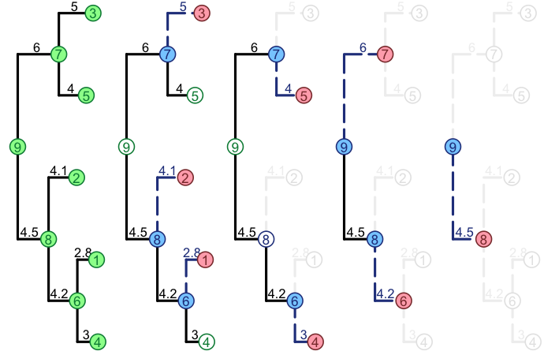

```
## C++ object <0x10875f910> of class 'SPLITT__OrderedTreeStringNodes' <0x10d46da20>
```

```r
par(mfrow=c(1,5))
par(mar=c(0,0,0,0))
par(oma=c(0, 0,0, 0))

PlotParallelTraversal(tree)
```